# NGS Workshop

Bioinformatics, Interpretation and Data Quality in Genome Analysis

Author

Prof Alfredo Iacoangeli and Mr Renato Santos

Published

2026

**Contacts:**  
- alfredo.iacoangeli@kcl.ac.uk  
- renato.santos@kcl.ac.uk

**Note**

This document is best viewed in a web browser.

# 1 Overview

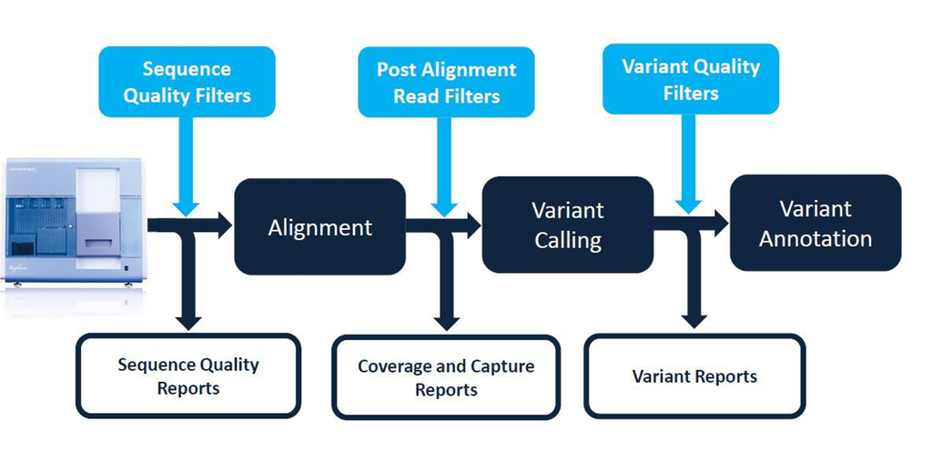

Figure 1: Basic overview of an NGS Pipeline

**The basic analysis of NGS data for clinical genetics involves the following steps:**

- quality control
- alignment (read mapping)
- variant calling
- variant annotation
- variant prioritisation
- reporting

It is essential to assess data quality and performance at each step.

**At the end of this workshop you will be able to:**

1. Use the Galaxy suite of bioinformatic tools
2. Assess the quality of raw NGS data in FASTQ format prior to alignment
3. Align NGS data to the reference human genome using BWA-MEM
4. Describe the contents of FASTQ, SAM and BAM files
5. Make an assessment of the alignment process
6. Conduct quality control filtering of reads
7. Visualise aligned data
8. Call variants and conduct quality control filtering and annotation of variants
9. Prioritise variants for follow-up/clinical reporting

At the beginning of relevant sections the main software used and its basic input and output formats will be listed.

**Tip**

Work through this workshop at your own pace. Read all sections carefully and if you’re unsure about anything, don’t be afraid to ask questions. Have fun!

**Warning**

Galaxy is an ongoing project, and bioinformatics tools and software are frequently updated. As a result, some screenshots in this document may not exactly match what you see on the live Galaxy site. Software versions may also differ. Don’t panic. Keep calm. The workflows, pipelines, and tools we use remain the same; there may only be minor differences. Use Galaxy’s search bar to find the tools you need, ask questions, search on Google, and report any bugs or typos.

## 1.1 Software used in this workshop

- [Galaxy Europe](https://usegalaxy.eu/)
- falco
- fastp
- [BWA-MEM](https://bio-bwa.sourceforge.net/)
- [samtools](https://www.htslib.org/doc/samtools.html)
- [picard](https://broadinstitute.github.io/picard/)
- [bedtools](https://bedtools.readthedocs.io/en/latest/)
- mosdepth
- freebayes
- [IGV](https://igv.org/)
- [bcftools](https://www.htslib.org/doc/bcftools.html)
- [Ensembl Variant Effect Predictor](https://www.ensembl.org/vep)

## 1.2 Illumina Sequencing Technology

A short overview of how the Illumina sequencing-by-synthesis (SBS) technology works.

- [Screencast](https://vimeo.com/121178846)
- [Slides](https://depot.galaxyproject.org/hub/attachments/documents/presentations/NGS101-Illumina.pdf)

### 1.2.1 Publications

- [Bentley, D. et al., 2008 Accurate whole human genome sequencing using reversible terminator chemistry.](https://doi.org/10.1038/nature07517)
  - The seminal paper describing the Illumina sequencing technology (originally developed by Solexa).
- [Kircher, M. et al., 2011. Addressing challenges in the production and analysis of illumina sequencing data.](https://doi.org/10.1186/1471-2164-12-382)
  - A practical guide for identifying and mitigating systematic errors and artifacts in Illumina sequencing.
- [Nakamura, K. et al., 2011. Sequence-specific error profile of Illumina sequencers.](https://doi.org/10.1093/nar/gkr344)
  - This paper shows that specific motifs, particularly inverted repeats and GGC triplets, can alter polymerase activity or cause single-stranded DNA to fold, resulting in reproducible false SNV calls and coverage bias.
- [Stoler, N. and Nekrutenko, A., 2021. Sequencing error profiles of Illumina sequencing instruments](https://doi.org/10.1093/nargab/lqab019)
  - This paper shows the differences between the newer 2-color sequencing systems (MiniSeq, NextSeq, and NovaSeq) and the older 4-color systems (MiSeq and HiSeq), leading to different error patterns.

# 2 The Workshop Case Study

The sequence data that you will be analysing is from a 3-year-old male who presented with difficulty walking after the first year of life, followed by muscle wasting and weakness, muscle rigidity, developmental delay, progressive vision loss leading to blindness, seizures, impaired swallowing, paralysis, and cognitive decline.

A brain MRI scan showed a “tigroid” (leopard‑skin) pattern within the deep white matter. Further clinical testing suggested a diagnosis of [Metachromatic leukodystrophy](https://medlineplus.gov/genetics/condition/metachromatic-leukodystrophy/) (MLD, also called Arylsulfatase A deficiency), which is a lysosomal storage disease commonly listed in the family of leukodystrophies as well as among the sphingolipidoses as it affects the metabolism of sphingolipids.

The patient’s exome was sequenced using the paired-end method on an [Illumina HiSeq 2500](https://support.illumina.com/sequencing/sequencing_instruments/hiseq_2500.html) following target enrichment using the [Nextera Rapid Capture Exome and Expanded Exome Enrichment Kits](https://support.illumina.com/sequencing/sequencing_kits/nextera-rapid-capture-exome-kit/documentation.html).

*This dataset is simulated but represents a realistic clinical scenario.*

## 2.1 Getting the Data

Download the test data from the links provided below.

| File | Description |
| --- | --- |
| WES01_chr22m_R1.fastq.gz | Illumina FASTQ read 1 |
| WES01_chr22m_R2.fastq.gz | Illumina FASTQ read 2 |
| chr22.genes.hg38.bed | Annotation BED file |

You should now have the files downloaded into a folder that looks something like Figure 2.

[figure not shown]

Figure 2: Workshop files downloaded into the Windows `Downloads` folder

# 3 Introduction to Galaxy

You will be using Galaxy to build and run your NGS pipeline. Galaxy is an open source, web-based platform and public servers hosted around the world, allowing scientists to analyse large datasets in a reproducible and collaborative way.

**Tip**

If you are new to Galaxy start here and consult the help resources.

**Learning Resources**

- [Galaxy NGS 101](https://galaxyproject.org/learn/galaxy-ngs101/) This page is designed to serve as a comprehensive resource describing manipulation and analysis of NGS data. While it is designed to highlight the utility of Galaxy it will also provide information that is broadly applicable and can be used for teaching of big data biology. It is accompanied by a collection of screencasts.
- [Galaxy Training](https://training.galaxyproject.org/)

**Getting more help on Galaxy**

- [FAQs and Guides](https://galaxyproject.org/support/)
- [GalaxyHelp Community Forum](https://help.galaxyproject.org/)

## 3.1 Sign in to Galaxy

**Important**

If you don’t have a Galaxy account, please register at https://usegalaxy.eu/register/start.

Go to https://usegalaxy.eu/login and sign in.

### 3.1.1 The Galaxy Interface

- The available software can be found in the **Tools** menu in the left panel.
- The central panel is your working area where you can visualise your data, select tool options and execute jobs.
- Your **History** is shown in the right hand panel. Here you will see your data, results, and a history of all the software that you have used.

[figure not shown]

Figure 3: The Galaxy page, with the Tools menu open.

### 3.1.2 The Galaxy Tools Interface

When a tool is selected, the central panel shows important information related to that tool.

An example is shown in Figure 4. This is for the software Freebayes: a Bayesian genetic variant detector designed to find small polymorphisms, specifically SNPs (single-nucleotide polymorphisms), indels (insertions and deletions), MNPs (multi-nucleotide polymorphisms), and complex events (composite insertion and substitution events) smaller than the length of a short-read sequencing alignment.

In this page, if you scroll down you will be able to find the following:

- **Tool name, Galaxy Version, and tool version selector and other Galaxy options**
- **Tool parameters** e.g. set input files, reference genome version, tool specific parameters.
- **What it does**
- **Description**
- **Galaxy-specific options**
- **Command-line parameters**
- **Acknowledgments**
- **References**

**Tip**

Don’t worry about memorising everything on this interface right now, you will become familiar with it as you work through the workshop.

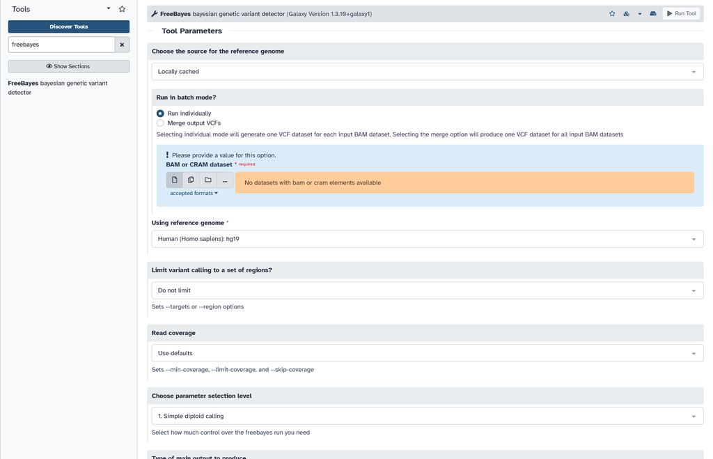

Figure 4: The Galaxy centre panel showing the Freebayes tool parameters.

## 3.2 Start a new Galaxy History

1. Ensure you are starting with a new empty history.
2. If your history is not empty, click the `+` button to create a new history.

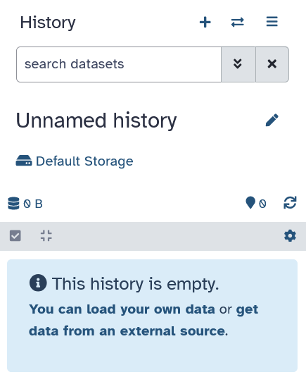

Figure 5: Example of an empty Galaxy History

3. Click on the `Edit ✎` button to rename this history.
4. Change the name to **WES01 NGS Workshop**.
5. Click the `Save` button.

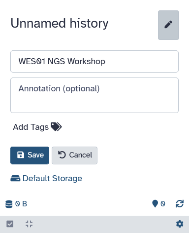

Figure 6: The panel to edit the history details

# 4 Data Upload

1. Click on `Upload`.

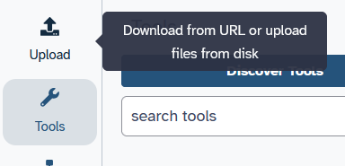

Figure 7: The `Upload` button on the left panel

2. On the top bar, above the box to drop files, click on `Collection`.
3. Change the **Collection:** type setting to `List of Pairs`.
4. Change the **Type (set all)** to `fastqsanger.gz`.
5. Click `Choose local file`.

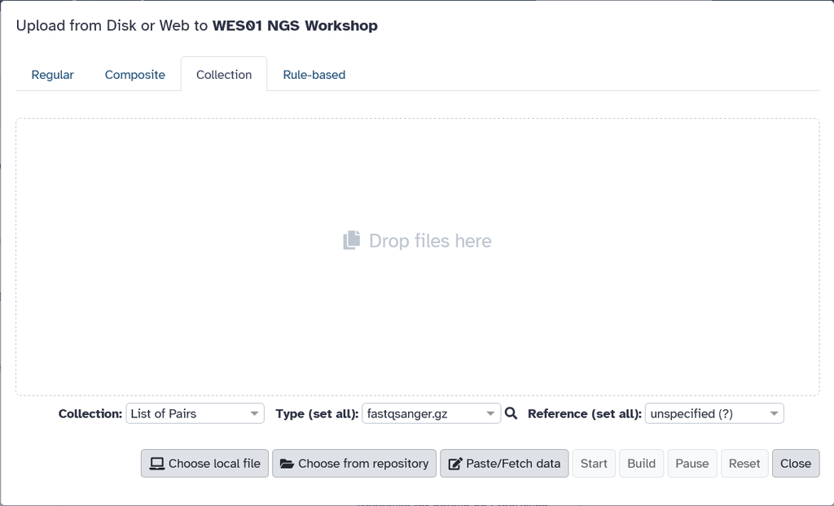

Figure 8: The Collection panel in the `Upload from Disk or Web` window

6. Navigate to the `Downloads` folder on your local computer and select the two `.fastq.gz` files and click `Open`.

[figure not shown]

Figure 9: The `Downloads` folder with the two `.fastq.gz` files highlighted

The files will appear in the **Upload from Disk or Web** window.

7. Click `Start` to begin the upload of the files.
8. Wait until the files are successfully uploaded and the `Build` button becomes enabled (it will turn blue). This may take some time, depending on server load.
9. Click on the `Build` button to create a list of paired `fastq` files.

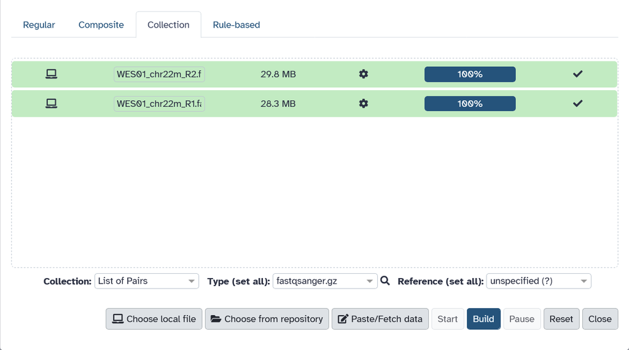

Figure 10: The `fastq` files were uploaded into the `Upload from Disk or Web` window, and the `Build` button is now enabled

10. Name the collection **WES01 fastq**.
11. Click on `Create collection`.

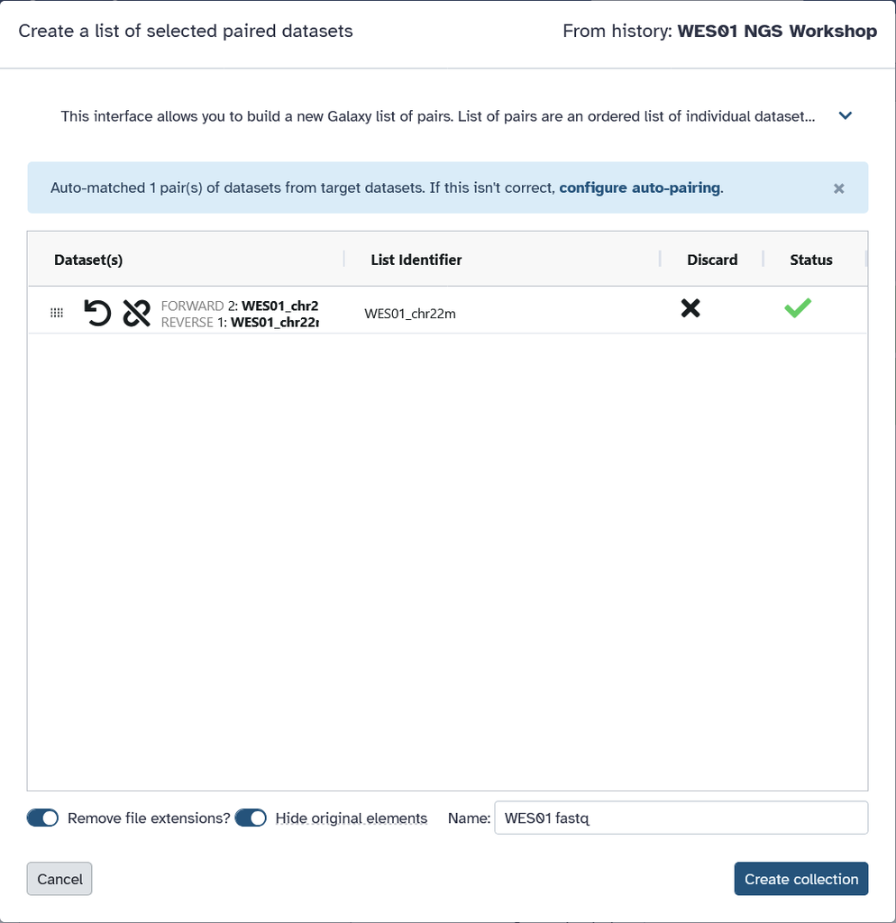

Figure 11: The **Create a list of selected paired datasets** window

A confirmation window will appear if the files were successfully paired.

12. Click `Exit` on the confirmation window.

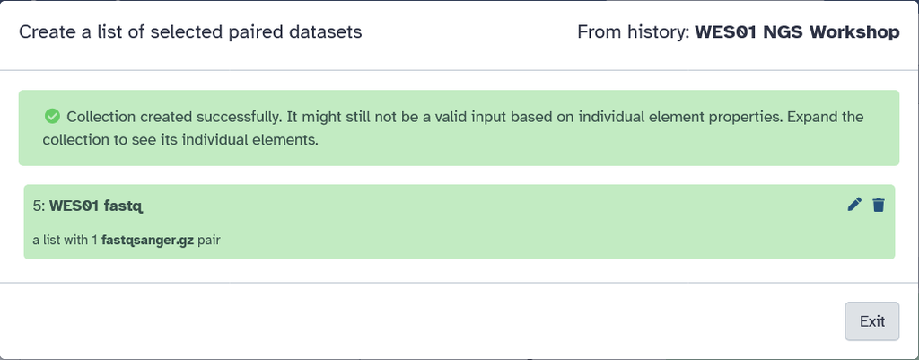

Figure 12: The confirmation window after the `fastq` files were paired

13. Open the `Upload from Disk or Web` window again.
14. On the top bar, above the box to drop files, click on `Regular`.
15. Click `Choose local file` again and upload the `chr22.genes.hg38.bed` file.
16. Change the file type to `bed`.
17. Change the genome reference to `Human Dec. 2013 (GRCh38/hg38)`.
18. Click `Start` to begin the upload of the `bed` file.
19. When the file has finished uploading, click `Close`.

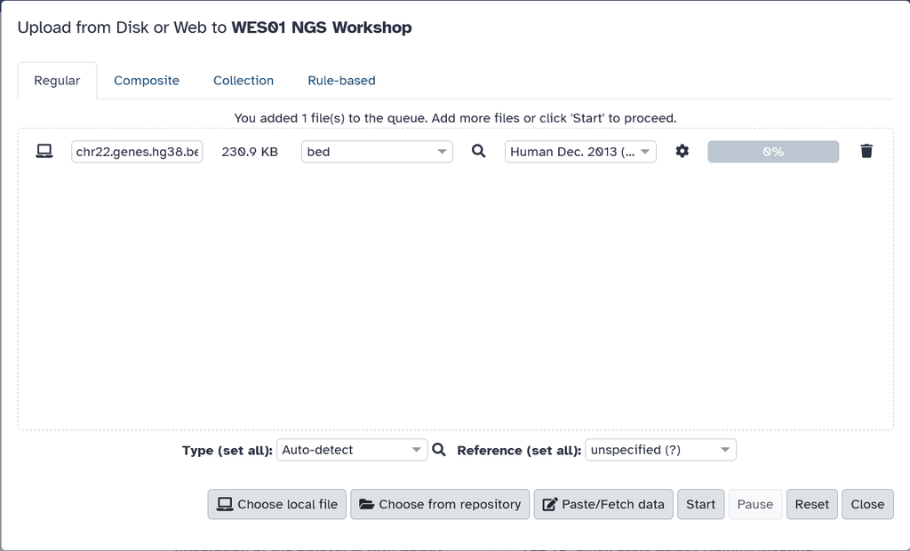

Figure 13: The Regular panel in the `Upload from Disk or Web` window

The uploaded data will appear in the History panel on the right.

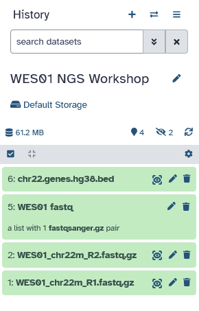

Figure 14: The History panel with the `.fastq.gz` and `.bed` files uploaded and ready for analysis.

**Tip**

You can inspect and view the contents of the data uploaded by clicking on the `View 👁` button next to the name of each file.

## 4.1 NGS Data Files and Formats

### 4.1.1 FASTQ Files

#### 4.1.1.1 Data Format

One lane of paired end sequencing was performed so you have two files of raw sequence data (`WES01_chr22m_R1.fastq.gz` and `WES01_chr22m_R2.fastq.gz`) which contain all the sequence data for read 1 (R1) and read 2 (R2) respectively (Figure 15). To save on computing time and disk space, the NGS data for WES01 has been filtered to contain reads mapping to chromosome 22 only and the files have been compressed with `gzip` (hence the `.gz` extension).

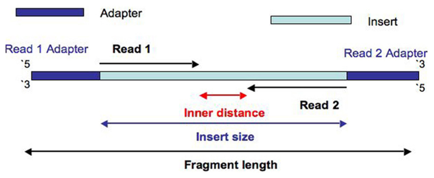

Figure 15: Diagram to show the construction of a fragment where an insert size is longer than the length of both reads.  
If the insert size is smaller than the sum of the read lengths the paired reads will overlap. Some analysis applications benefit from some overlap between Read 1 and Read 2.  
Source: Turner, F.S., 2014. Assessment of insert sizes and adapter content in fastq data from NexteraXT libraries. Frontiers in genetics, 5, p.77572.

The raw NGS data is held in [FASTQ format](https://en.wikipedia.org/wiki/FASTQ_format). `fastq` files are the simplest and most generic way of storing biological sequences and their corresponding quality scores.

A `fastq` file has four line-separated fields per sequence:

- Line 1 begins with an `@` character and is followed by a sequence identifier and an optional description (like a FASTA title line).
- Line 2 is the raw sequence letters.
- Line 3 begins with a `+` character and is optionally followed by the same sequence identifier (and any description) again.
- Line 4 encodes the quality values for the sequence in Line 2, and must contain the same number of symbols as letters in the sequence.

A `fastq` file containing a single sequence might look like this:

```
@HWI-D00119:50:H7AP8ADXX:1:1212:10369:36657/1
GCACGTGGGTTCCCAGTAGCAAGAAACTAAAGGGTCGCAGGCCGGTTTCTGCTAATTTCTTTAATTCCAAGACAGTCTCAAATATTTTCTTATTAACTTCC
+
CCCFFFFFHHHHHJJJHIJJJJJJJJJJJJJJJJHFGIIIGJJJJIIHHHHHHFFFFFFFEEEEEEEEEDDDDDDDDDDEDDDDFFEEEDDDDEEEDDEDD
```

#### 4.1.1.2 Illumina sequence identifiers

Sequences from the [Illumina instruments](https://help.basespace.illumina.com/files-used-by-basespace/fastq-files#format) use systematic identifiers.

```
@EAS139:136:FC706VJ:2:2104:15343:197393 1:Y:18:ATCACG
```

| Value | Description |
| --- | --- |
| **EAS139** | the unique instrument name |
| **136** | the run id |
| **FC706VJ** | the flowcell id |
| **2** | flowcell lane |
| **2104** | tile number within the flowcell lane |
| **15343** | ‘x’-coordinate of the cluster within the tile |
| **197393** | ‘y’-coordinate of the cluster within the tile |
| **1** | the member of a pair, 1 or 2 (paired-end or mate-pair reads only) |
| **Y** | Y if the read is filtered, N otherwise |
| **18** | 0 when none of the control bits are on, otherwise it is an even number |
| **ATCACG** | index sequence |

**Note**

More recent versions of Illumina software output a sample number (as taken from the sample sheet) in place of an index sequence.

For example, the following header might appear in the `fastq` belonging to the first sample of a batch of samples: `@EAS139:136:FC706VJ:2:2104:15343:197393 1:N:18:1`

#### 4.1.1.3 Phred Quality Scores

A [Phred quality score](https://en.wikipedia.org/wiki/Phred_quality_score) is a measure of the quality of the identification of the sequence of bases generated by automated DNA sequencing.

A phred score or quality value Q is an integer mapping of p (i.e., the probability that the corresponding base call is incorrect).

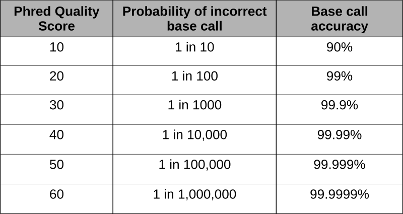

Figure 16: Phred quality scores and their corresponding probabilities of base accuracy

- https://en.Wikipedia.org/wiki/FASTQ_format#Quality
- https://en.Wikipedia.org/wiki/FASTQ_format#Encoding

It is more efficient to store the sequence quality scores as characters because they require less disk space than numbers (i.e. 1 character versus multiple digits). Characters are also more reliable and portable than numbers. Sequence quality scores on the phred scale are determined by mapping the ASCII character to its associated number.

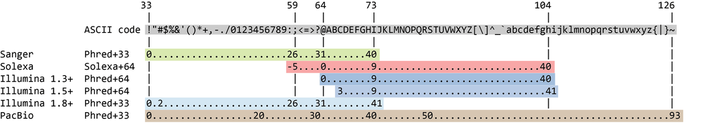

Figure 17: The different Phred quality scores encoding standards, and their corresponding ASCII characters

### 4.1.2 BED Files

The uploaded file `chr22.genes.hg38.bed` describes the exome sequences and genes that have been targeted in your trial data, stored in `.bed` format. A **BED** file is a tab-delimited text file that defines genomic features.

Briefly, the BED format consists of one line per feature, each containing 3-12 columns of data, plus optional feature definition lines. A minimal `.bed` file uses 3-4 tab delimited columns of data to describe the target:

The first three fields in each feature line are required:

1. **chrom** - Chromosome (e.g. chr3, chrY, chr2_random) or scaffold (e.g. scaffold10671) name
2. **chromStart** - Start coordinate on the chromosome for the sequence considered (this position is zero-based, i.e. the first base on a chromosome is 0).
3. **chromEnd** - End coordinate on the chromosome for the sequence considered; this position is non-inclusive, unlike chromStart (this position is one-based, i.e. the first base on a chromosome is 1)
4. **name** - Name of the feature in that line.

Let’s have a quick look at `chr22.genes.hg38.bed`

```
chr22   15721285    15721631    POTEH-chr22-16256332-16256677
chr22   15719659    15719778    POTEH-chr22-16258185-16258303
chr22   15710867    15711034    POTEH-chr22-16266929-16267095
chr22   15708019    15708090    POTEH-chr22-16269873-16269943
chr22   15702685    15702756    POTEH-chr22-16275207-16275277
chr22   15700077    15700215    POTEH-chr22-16277748-16277885
chr22   15698661    15698768    POTEH-chr22-16279195-16279301
chr22   15690025    15690709    POTEH-chr22-16287254-16287937
chr22   15528158    15529137    OR11H1-chr22-16448826-16449804
chr22   16590757    16592810    CCT8L2-chr22-17071648-17073700
```

# 5 Pre-alignment QC

**Note**

- **Software**
  - falco
  - fastp
- **Input/Output**
  - falco input (collection of raw fastq files):
    - `WES01_chr22m_R1.fastq.gz`
    - `WES01_chr22m_R2.fastq.gz`
  - falco output:
    - `html` report
      - forward
      - reverse
    - stats text file
      - forward
      - reverse
  - fastp input (collection of raw fastq files):
    - `WES01_chr22m_R1.fastq.gz`
    - `WES01_chr22m_R2.fastq.gz`
  - fastp output (collection of quality filtered fastq files):
    - `WES01_chr22m_R1.fastp.fastq.gz`
    - `WES01_chr22m_R2.fastp.fastq.gz`
    - `html` report
    - stats `JSON` file

## 5.1 Extract Read Group Information

1. View the `fastq` files and note the following information:
   - The unique instrument name
   - The run id
   - The flowcell id
   - The flowcell lane

This information can be obtained from the sequence identifier i.e. line 1 of the first fastq entry.

```
Header: @HWI-D00119:50:H7AP8ADXX:1:1212:10369:36657/1
            |       |     |      |
mapping:    1       2     3      4
```

1. The unique instrument name:**HWI-D00119**
2. The run id: **50**
3. The flowcell id: **H7AP8ADXX**
4. The flowcell lane: **1**

**Tip**

For more information on `fastq` headers please see the Illumina sequence identifiers section.

**Important**

We will use this information later, during the alignment process, to add metadata, such as read group and run information, to the sample we are analysing.

## 5.2 Quality assessment of raw sequence data

To assess the quality of the raw sequence data and to guide quality control we will use a program called `falco`, short for *FastQC Alternative Code*. The program outputs summary plots and text files that show if there are any problems with the data, which could influence alignment or variant calling if not addressed.

You can learn more about `falco` [here](https://github.com/smithlabcode/falco), and the older (and slower) program on which it is based, `FastQC` [here](https://www.bioinformatics.babraham.ac.uk/projects/fastqc/).

1. In the Tool Panel select the `Falco` tool.
2. For the `Raw read data from your current history` choose `Dataset collection` (the third button) and then ensure the `WES01 fastq` collection is selected.
3. Click on the `Run Tool` button to execute the analysis.

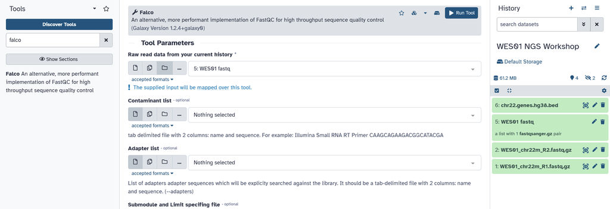

Figure 18: The `falco` tool panel, with the `WES fastq` file collection selected as input for the tool

The FastQC reports will be shown in the History Pane. Queued jobs are shown in grey with a clock symbol, running jobs in yellow with a buffering symbol, and finished jobs in green, failed jobs in red with a cross.

Depending on server load, it may take a little while for the jobs to start running.

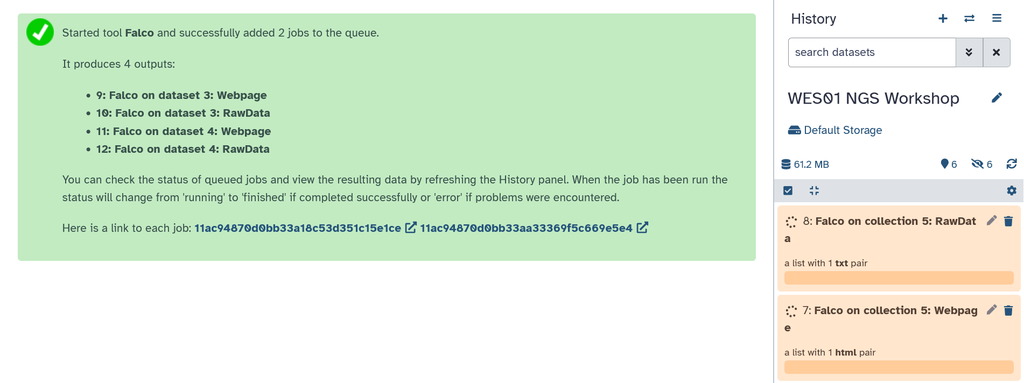

Figure 19: The confirmation screen for the `falco` jobs submission, with the jobs being shown running on the history panel to the right

4. Click on `Falco on collection 5: Webpage`, then on `WES01_chr22`, and then the view button for the `forward` and `reverse` files to view the respective QC reports.

#### 5.2.0.1 Questions

**Important**

Use the html `falco` reports from the `forward` and `reverse` sequencing data to answer the following questions.

For questions 1 and 2, type your answer in the box and press `Check`. For the multiple choice questions (3–6), click on an option to check your answer.

1. How many reads does each file contain?

   Both files contain 505,987 reads. The forward and reverse files of a paired-end run should contain the same number of reads, as each read in one file is paired with a read in the other.
2. How long are the reads (bp)?

   All reads are 101 bp long, in both files.
3. Which of the following quality checks has **failed** in **both** the `forward` and `reverse` files?
   - Per base sequence quality and Adapter Content
   - Overrepresented sequences and Sequence Length Distribution
   - Per base sequence content and Per sequence GC content
   - None of the above

   Both files fail *Per base sequence content* and *Per sequence GC content*, and give a warning for *Adapter Content*. A failed module does not necessarily mean the data is unusable: `falco` (like `FastQC`) assumes a random, whole-genome library, and some modules routinely fail for targeted sequencing data such as exomes.
4. Look at the *Per base sequence content* plots of the `forward` and `reverse` reads. What do they show, and what is the most likely reason this check has failed?
   - The four lines overlap at 25% each along the whole read, so the check has failed in error
   - The four lines drift apart towards the end of the reads, because base quality falls there
   - The four lines are far apart along the whole length of the reads, because the sample is contaminated
   - The four lines are uneven over the first ~15 bases and then flat and parallel, because library preparation introduces a sequence bias at the start

   In a random library, the proportions of A and T, and of G and C, should be nearly equal at every position, giving flat, parallel lines. `falco` fails this module if A and T, or G and C, differ by more than 20% at any position. Here G and C differ by almost 30% at base 4, but from about base 16 onwards the lines settle at G ≈ C ≈ 28% and A ≈ T ≈ 22%, consistent with the high GC content of this sample.

   The bias appears at the same positions in both files, so it was introduced when the library was made, not by the sequencer. The Nextera transposase enzymes used to fragment and tag the DNA prefer certain sequences, so the first bases of each read are not random.
5. Compare the *Per base sequence quality* plots of the `forward` and `reverse` reads. Which statement best describes them?
   - Quality declines towards the end of the reads
   - Quality is constant along the full length of the reads
   - Quality is lowest at the start of the reads and improves towards the end
   - The `forward` reads have lower quality than the `reverse` reads at every position

### 5.2.1 Per base sequence quality

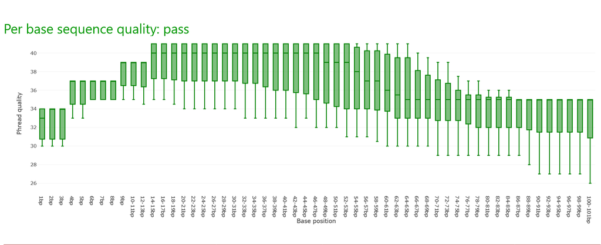

Figure 20: Per base sequence quality plot of the forward `fastq` reads (`WES01_chr22m_R1.fastq.gz`)

Looking at the per base sequence quality for the forward reads you will notice that the average base quality drops towards the end of the reads (Figure 20).

This drop in quality is typical for ensemble-based sequencing by synthesis (SBS) methods, such as Illumina, which add complementary bases one at a time in a cluster of identical sequences to determine a consensus sequence from the ‘average’ sequence signal over all copies in the cluster.

As nucleotides are added some of the sequences in a cluster grow at a different rate and become desynchronized which reduces the accuracy of the ‘average’ sequence signal (Figure 21).

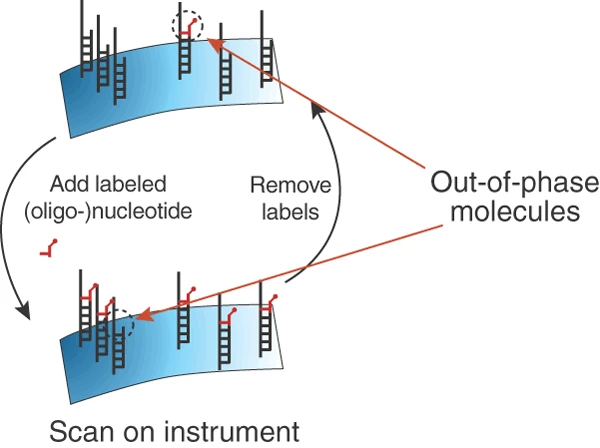

Figure 21: For ensemble sequencing methods, thousands of identical copies of a DNA sequence are synthesised together. Whenever synthesis lags behind or steps ahead, signal is lost and background increases. Ultimately, this limits the length over which synthesis can be read.  
Source: Fuller, C., Middendorf, L., Benner, S. et al. The challenges of sequencing by synthesis. Nat Biotechnol 27, 1013–1023 (2009).

Another particularly important plot is that of ‘Overrepresented sequences’, which lists sequences that account for more than 0.1% of the total. The presence of an overrepresented sequence suggests that the sequence is biologically significant, or that the library is contaminated or has low diversity.

To check for contamination, each overrepresented sequence is compared to a database of common contaminants such as sequencing adapters, which can then be removed from the raw `fastq` data.

## 5.3 Read filtering

In a typical analysis you may want to raise technical issues identified by `falco`, such as low read count, poor quality, and overrepresented sequences with the data provider. To ensure that only data of a certain quality is used for further analysis we will exclude low quality reads.

In paired-end data there are two `fastq` files per lane of sequencing which are synchronised so that matching pairs are stored in the same line of each file (e.g. the read in line 1, file 1 is paired with the read in line 1, file 2 and so on).

The fastq files need to be joined and the reads have to be analysed and trimmed or removed as a pair. To maintain this order when filtering, we will filter the `fastq` files using [`fastp`](https://github.com/OpenGene/fastp).

1. In the Tool Panel select the `fastp` tool.
2. For the `Single-end or paired reads` section choose `Paired collection` and then ensure the `WES01 fastq` collection is selected.
3. Open the `Adapter Trimming Options` section and enable `Adapter sequence auto-detection for paired-end`.

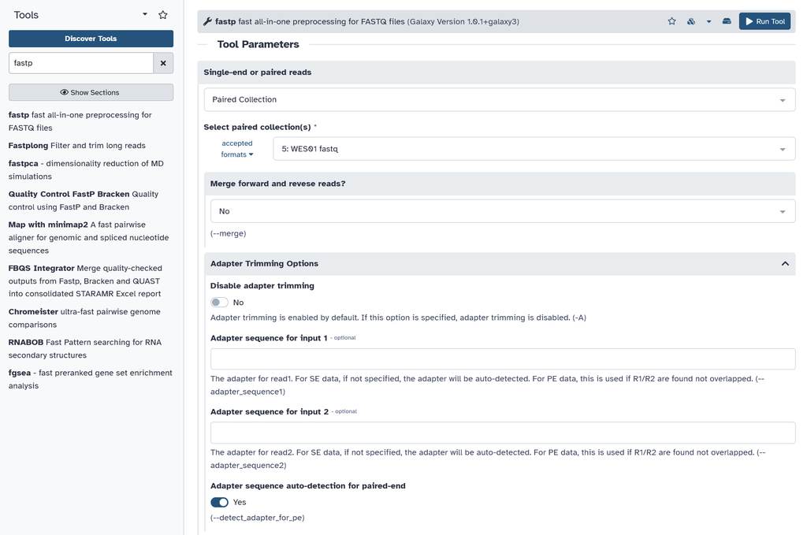

Figure 22: The `fastp` tool panel, with the `WES fastq` file collection selected as input for the tool, and the option `Adapter sequence auto-detection for paired-end` enabled

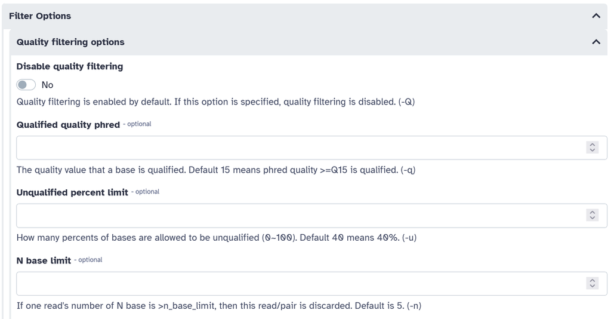

Figure 23: The `Quality filtering options` on the `fastp` tool panel

5. Open the `Length filtering options`. Note that, by default, `fastp` will discard reads shorter than 15 base pairs. Set the `Length required` parameter to `40`. This will discard reads shorter than 40 base pairs.
6. Open the `Read modification options`, and then `Per read cutting by quality options`. Set the lower `Cut by quality in tail (3') (Move a sliding window from front to tail)` to `Yes` and ensure the `Cutting window size for cut right` is set to `4` and `Cutting mean quality for cut right` is set to `20`.
7. Click on the `Run Tool` button to execute quality filtering.

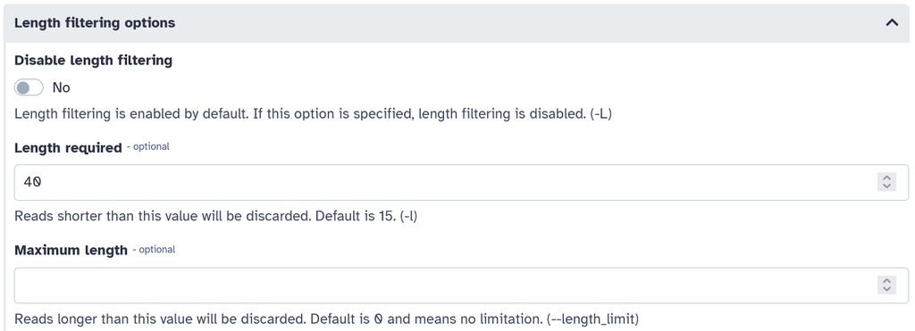

Figure 24: The `Length filtering options` on the `fastp` tool panel

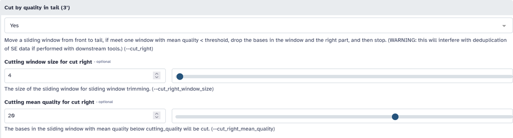

Figure 25: The `Read modification options` on the `fastp` tool panel

You should now have set up 3 `fastp` operations:

1. Enabled `Adapter sequence auto-detection for paired-end`
2. Discard reads below a specified length (40bp)
3. Per read cutting by quality: trim the 3’ end of each read using a sliding window (`Cut by quality in tail (3')`), moving from front to tail with a window size of 4 and cutting when the mean quality in the window drops below Q20

We are also using the default `fastp` quality filtering options, which include discarding reads with more than 40% of bases with less than Q15, and reads with more than 5 *N* nucleotides.

For paired-end data a particular strength of `fastp` is that it retains the pairing of reads (from R1 and R2) in the filtered output files.

The two `fastq` files (R1-paired and R2-paired) contain one read from each pair where both have survived filtering. Additionally, `fastp` can also output two `fastq` files (R1-unpaired and R2-unpaired) which contain reads where one of the pair failed the filtering steps, although this is currently not supported by the `fastp` version on Galaxy.

## 5.4 Quality assessment of read filtering

1. When the `fastp on collection 5: HTML report` has finished, click on the collection to open it, and then click on the `View 👁` button to view the report.

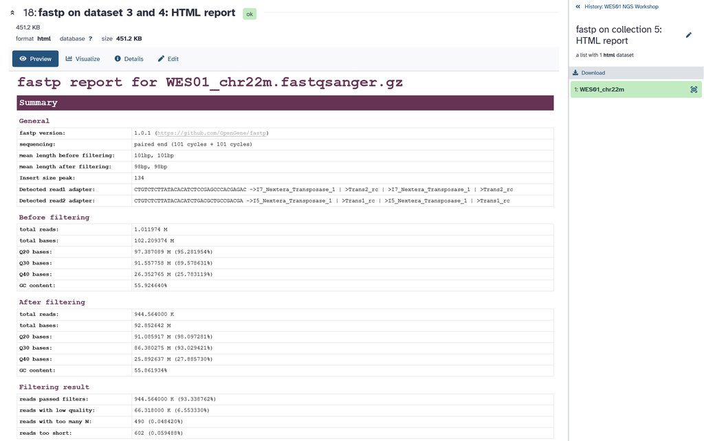

Figure 26: The `fastp` quality filtering report

2. Check whether `fastp` detected the adapter sequences automatically, and whether they correspond to the sequences below, which were used in the [Nextera Rapid Capture Exome and Expanded Exome Enrichment Kits](https://support.illumina.com/sequencing/sequencing_kits/nextera-rapid-capture-exome-kit/documentation.html).

The Nextera adapters used are:

```
Read1  I7_Nextera_Transposase_1  CTGTCTCTTATACACATCTCCGAGCCCACGAGAC
Read2  I5_Nextera_Transposase_1  CTGTCTCTTATACACATCTGACGCTGCCGACGA
```

[Further Reading](https://knowledge.illumina.com/library-preparation/general/library-preparation-general-reference_material-list/000001314): what sequences do we use for adapter trimming?

**Tip**

If the adapter sequences were not correctly detected by `fastp`, it means that it could not correctly attempt to overlap the forward and reverse reads. Check that you correctly uploaded both the `R1` and `R2` `fastq.gz` files.

**Note**

`fastp` includes many adapter sequences in its database, but it is not exhaustive. If `fastp` does not detect your adapters in a future experiment, you would need to provide the adapter sequencers to the tool so it can trim them correctly.

However, please note that many modern sequencers and basecalling pipelines now perform adapter trimming automatically, so adapters may not always be detected at this stage and may not need to be trimmed.

3. Check the quality control results, before and after filtering.

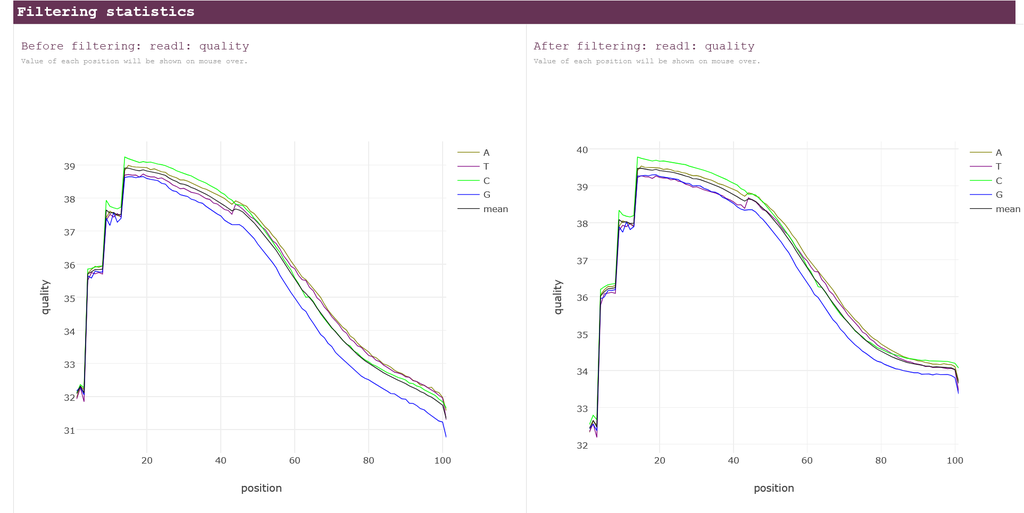

Figure 27: Filtering statistics for read 1, before filtering on the left, and after filtering on the right

There are other ways to clean up reads more agressively, such as applying stricter filtering criteria, which may be appropriate depending on data quality and analysis requirements. However, these approaches can reduce usable data and should be used with caution.

#### 5.4.0.1 Questions

**Important**

Use the `fastp` report to answer the following questions.

1. How many reads does **each** file contain after quality filtering? (Hint: `fastp` reports the total for the `forward` and `reverse` files combined.)

   Note that 48% of the read pairs could not be overlapped, so their insert size is unknown: it is either shorter than 30 bp or longer than 172 bp (or the reads contain too many sequencing errors).
5. Compare the read 1 quality plots before and after filtering (Figure 27). Has the read quality improved?
   - Yes, mean quality is higher, but it still declines towards the 3’ end of the reads
   - Yes, but only improved at the start of the reads
   - Yes, quality is now constant along the whole read
   - No, the plots are identical

   The data was already close to specification before filtering (~90% of bases at Q30 or higher), so trimming was not essential for it to pass QC.

   Modern aligners such as BWA-MEM can soft-clip poor-quality read ends, and variant callers generally take base quality into account, so stricter trimming is rarely needed for data of this quality. In your own experiments, weigh the loss of data against the gain in quality.

# 6 Alignment

**Note**

- **Software**
  - `BWA-MEM`
- **Input/Output**
  - `BWA-MEM` input: Reference Genome and indexes for use with bwa
    - hg38 reference genome (`fasta` file)
    - `BWA-MEM` indexes (provided by Galaxy):
      - `.amb` is text file, to record appearance of N (or other non-ATGC) in the ref `fasta`.
      - `.ann` is text file, to record ref sequences, name, length, etc.
      - `.bwt` is binary, the Burrows-Wheeler transformed sequence.
      - `.pac` is binary, packaged sequence (four base pairs encode one byte).
      - `.sa` is binary, suffix array index.
    - `BWA-MEM` input (paired `fastq` files):
      - `WES01_chr22m_R1.fastp.fastq.gz`
      - `WES01_chr22m_R2.fastp.fastq.gz`
  - `BWA-MEM` output (aligned sequences file):
    - `.bam` file
    - `.bai` (`bam` index: automatically produced by Galaxy)

## 6.1 Align sequence data to the reference human genome

We will use a program called `BWA-MEM` (Burrows-Wheeler Aligner) to align the sequence data to the human genome. You can learn more about the `BWA` program [here](http://bio-bwa.sourceforge.net/).

1. In the Tool Panel select the `Map with BWA-MEM` tool.
2. For the `Will you select a reference genome from your history or use a built-in index?`, ensure `Use a built-in genome index is selected`, then choose `Human Dec. 2013 (GRch38/hg38)` as the reference genome.
3. In the section `Single or Paired-end reads`, select `Paired Collection` as your data type, then select `fastp on collection 5: Paired-end output` as your data collection.

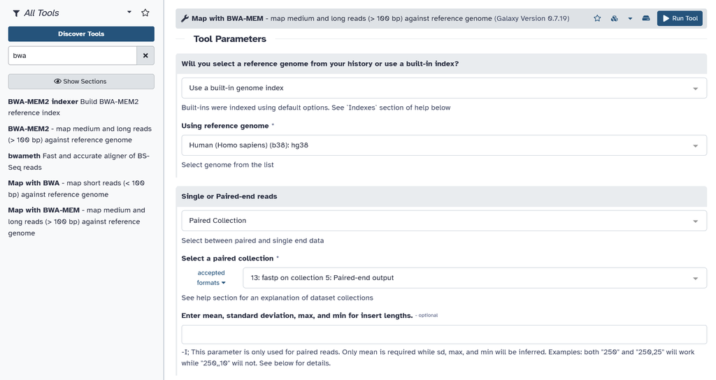

Figure 28: Subsection of the tool parameters in the `Map with BWA-MEM` tool panel

## 6.2 Set read groups per the SAM/BAM specification

**Warning**

This next step is very important! Please do not skip it.

**Tip**

Please see the Extract Read Group Information section to remember how this information was obtained.

4. In the section `Set read groups information?`, select the option `Set read groups (SAM/BAM specification)`.
5. Enter the following for the options:
   - Read group identifier (ID): `HWI-D00119.50.H7AP8ADXX.1.WES01`
   - Read group sample name (SM): `WES01`
   - Platform/technology used to produce the reads (PL): `ILLUMINA`
   - Library name (LB): `nextera-wes01-blood`

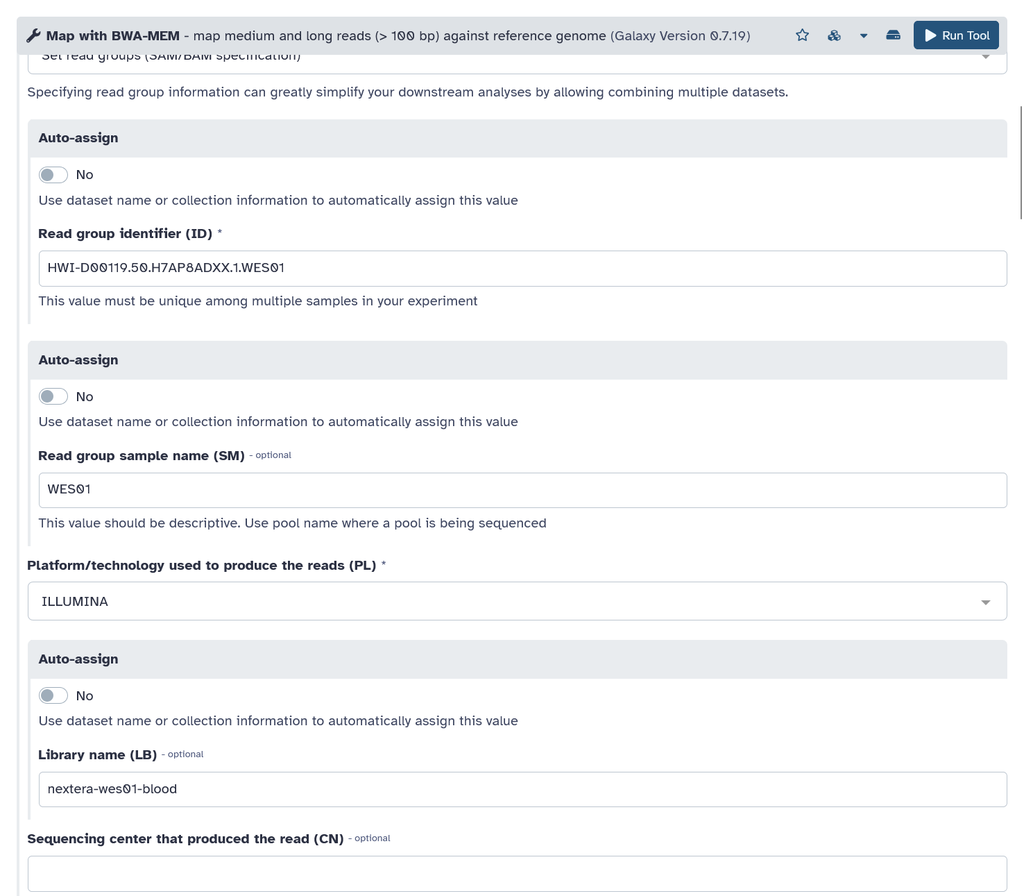

Figure 29: Subsection of the tool parameters in the `Map with BWA-MEM` tool panel

6. Continue entering the following options
   - Date that run was produced (DT): `2017-02-23`
   - Platform unit (PU): `H7AP8ADXX.1`
7. Click on the `Run Tool` button to execute the analysis.

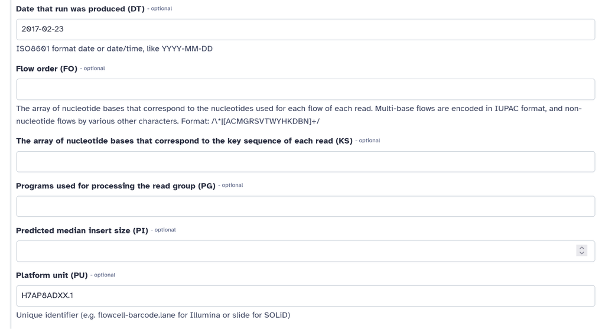

Figure 30: Subsection of the tool parameters in the `Map with BWA-MEM` tool panel

[Additional Reference](https://gatk.broadinstitute.org/hc/en-us/articles/360035890671-Read-groups): what are read groups?

## 6.3 A new NGS Data Format

### 6.3.1 The Binary Alignment/Map file (BAM)

The alignment process maps the read data to the reference human genome creating a **Binary Alignment/Map file (BAM)**. The `bam` file is not in text format, so it is not directly viewable. Clicking the view button will open the alignment on IGV (Integrative Genomics Viewer).

[Additional Reference](https://galaxyproject.org/learn/galaxy-ngs101/#understanding-and-manipulating-sambam-datasets): understanding and manipulating SAM/BAM datasets

# 7 Post Alignment QC and Filtering

**Note**

For variant calling, reads with low mapping quality (phred <20), unmapped reads, secondary alignments, reads failing platform/vendor quality checks, and duplicate reads that have the same start and stop position are typically removed or ignored because they can influence genotyping accuracy.

Duplicates originate mostly from DNA library preparation methods that rely on PCR amplification, which can create multiple sequencing reads from the same original DNA molecule (PCR duplicates) and thus artificially inflate read depth and bias allele fractions. Other sources include optical duplicates (sequencing clusters imaged more than once) and platform-specific artefacts.

For example, at heterozygous sites the two alleles should be evenly distributed (50% of reads have the A allele and 50% have the B allele) but if reads with the A allele are duplicated the A allele will become overrepresented and the site might be misinterpreted as homozygous for the A allele.

We will use `Picard MarkDuplicates` and then `samtools view` to make a new BAM file which flags duplicate molecules and excludes poor quality reads.

[Additional Reference](https://www.cureffi.org/2012/12/11/how-pcr-duplicates-arise-in-next-generation-sequencing/): How PCR duplicates arise in next-generation sequencing

## 7.1 MarkDuplicates

1. In the Tool Panel select the `MarkDuplicates` tool.
2. Select `Dataset collection` (the third button) as your data type, then select `Map with BWA-MEM on collection 13 (mapped reads in BAM format)` as your data collection.
3. Leave all other settings on their default options.
4. Click on the `Run Tool` button to execute the analysis.

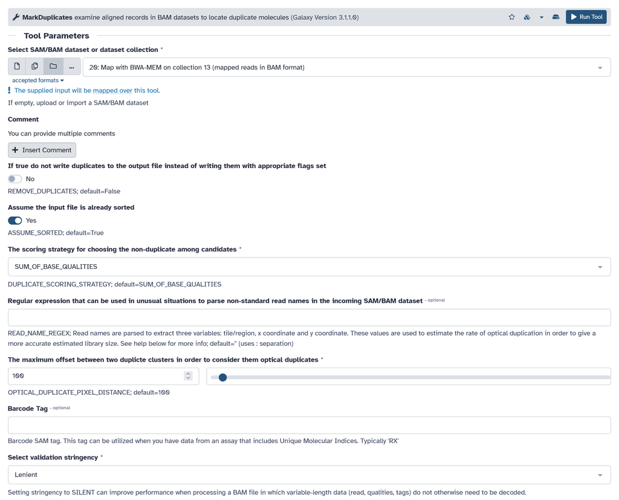

Figure 31: The `Picard MarkDuplicates` tool panel, with the mapped `bam` file loaded as input

This tool examines aligned records in the supplied SAM or BAM dataset to locate duplicate molecules. All records are then written to the output file with the duplicate records flagged. Two files are produced, 1) the new BAM file with duplicate reads marked and 2) a metrics file summarising the number of duplicate reads found.

## 7.2 Filter BAM based on mapping quality and bitwise flags

1. In the Tool Panel select the `Filter SAM or BAM, output SAM or BAM files on FLAG MAPQ RG LN or by region` tool.
2. Select `Dataset collection` as your data type, then select `MarkDuplicates on collection 20: BAM` as your data collection.
3. For `Minimum MAPQ quality score` type `30`.
4. On the section `Filter on bitwise flag` select `yes`.
5. Select the following options on `Skip alignments with any of these flag bits set`:
   - `The read is unmapped`
   - `The alignment or this read is not primary`
   - `The read fails platform/vendor quality checks`
   - `The read is a PCR or optical duplicate`
6. Leave all other settings on their default options.
7. Click on the `Run Tool` button to execute the analysis.

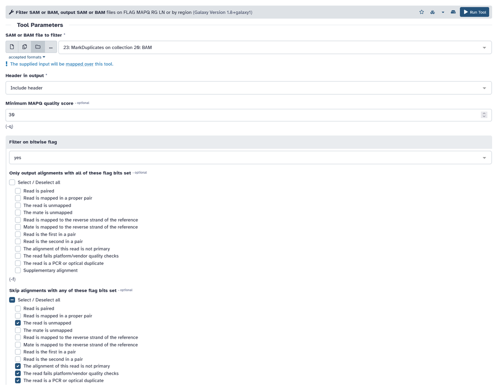

Figure 32: The `Filter SAM or BAM` tool panel, with the duplicate-marked `bam` file loaded as input, and relevant options set

This tool uses the `samtools view` command in the `samtools` toolkit to filter a `sam` or `bam` file on the MAPQ (mapping quality), FLAG bits, Read Group, Library, or region.

The input is a `bam` file, and the output file will also be `bam`.